# Massachusetts Outcome Analysis Exploration

Julie Ghekas

20 June, 2016

Outcome analysis is performed here for Massachusetts. The matching scheme that we selected used an unweighted glm to generate the propensity scores, full matching retaining 1/4 of the potential control counties, and a population-weighted balance assessment. The groups formed from this procedure will function as the two groups to be compared to assess if the outcomes are different. The full pool of potential comparisons, i.e. all counties not in Massachusetts, may be used at various points in time, but these are not the primary comparisons of interest.

```r
setwd('~')
library(reshape2)
library(car)
library(RItools)
library(optmatch)
library(brglm)
library(MASS)
library(geepack)

load('pop99.Rdata')
load('mort99.Rdata')
load('model2data.Rdata')
model2=glm(treat~a2034+a3544+a4554+male+white+black+hisp+mr01+mr02+mr03+mr04+mr05+mr06+
             pov06+medinc06+unemp06+ins06,data=model2data,family=binomial(link='logit'))
fm2<-fullmatch(model2,data=model2data,omit.fraction=3/4)
model2fit = cbind(model2data, fm2)
model2fit = model2fit[,c(1,2,31)]

popyr = subset(pop99, pop99$year>=2001)
popyr = subset(popyr, popyr$type==3)
popyr$a2034 = popyr$a2024 + popyr$a2534
popyr$pops = popyr$a2034 + popyr$a3544 + popyr$a4554 + popyr$a5564
popsyr = aggregate(pops~county+state+year, sum, data=popyr)

ageyr = aggregate(cbind(a2034, a3544, a4554, a5564)~county+state+year, sum, data=popyr)
ageyr = cbind(ageyr[,1:3],100*t(apply(ageyr[,4:7],1,prop.table)))

rsyr = aggregate(cbind(count=a2034+a3544+a4554+a5564)~racesex+county+state+year,sum,
                 data=popyr)
ryr = rsyr
ryr$race = recode(ryr$racesex, "1:2=1; 3:4=2; 5:8=3")
ryr$race[ryr$race==1] = 'white'
ryr$race[ryr$race==2] = 'black'
ryr$race[ryr$race==3] = 'otherrace'
racesyr = aggregate(count~race+county+state+year, sum, data=ryr)
racesyr = dcast(data=racesyr, state+county+year~race)
raceyr = cbind(racesyr[,1:3],100*t(apply(racesyr[,4:6],1,prop.table)))

syr = rsyr
syr$sex = recode(syr$racesex, "1=1; 2=2; 3=1; 4=2; 5=1; 6=2; 7=1; 8=2")
syr$sex[syr$sex==1]='male'
syr$sex[syr$sex==2]='female'
sexesyr = aggregate(count~sex+county+state+year, sum, data=syr)
sexesyr = dcast(data=sexesyr, state+county+year~sex)
sexyr = cbind(sexesyr[,1:3], 100*t(apply(sexesyr[,4:5],1,prop.table)))

hispyr = aggregate(cbind(count=a2034+a3544+a4554+a5564)~hisp+county+state+year, sum,
                   data=popyr)
hispyr$hisp = recode(hispyr$hisp, '2=1;1=2;9=2')
hispyr$hisp[hispyr$hisp==1] = 'hisp'
hispyr$hisp[hispyr$hisp==2] = 'nothisp'
hispsyr = aggregate(count~hisp+county+state+year, sum, data=hispyr)
hispsyr = dcast(data=hispsyr, state+county+year~hisp)
hispyr = cbind(hispsyr[,1:3],100*t(apply(hispsyr[,4:5],1,prop.table)))

mortyr = subset(mort99, mort99$year>=2001)
mortyr = subset(mortyr, mortyr$age>=09 & mortyr$age<=13)
deathsyr = aggregate(deaths~county+state+year, sum, data=mortyr)

yeardata = merge(deathsyr, popsyr, by=c('state','county','year'))
yeardata = merge(yeardata, ageyr, by=c('state','county','year'))
yeardata = merge(yeardata, raceyr, by=c('state','county','year'))
yeardata = merge(yeardata, sexyr, by=c('state','county','year'))
yeardata = merge(yeardata, hispyr, by=c('state','county','year'))
yeardata$treat = 0
yeardata$treat[yeardata$state==25 & yeardata$year>=2006] = 1
yeardata$idvar = paste(yeardata$state, yeardata$county, sep=',')


year.group = merge(yeardata, model2fit, by=c('state','county'), all=T)
year.group = year.group[order(year.group$state, year.group$county, year.group$year),]
year.group = subset(year.group, !is.na(year.group$fm2))
year.group$idvar = as.factor(year.group$idvar)

massgee = geese(deaths/pops~a2034+a3544+a4554+black+otherrace+female+hisp+treat+
                  strata(fm2), id=idvar, family=gaussian, data=year.group, waves=year)
summary(massgee)
```

```
##
## Call:
## geese(formula = deaths/pops ~ a2034 + a3544 + a4554 + black +
##     otherrace + female + hisp + treat + strata(fm2), id = idvar,
##     waves = year, data = year.group, family = gaussian)
##
## Mean Model:
##  Mean Link:                 identity
##  Variance to Mean Relation: gaussian
##
##  Coefficients:
##                      estimate       san.se         wald            p
## (Intercept)      7.703095e-03 1.453845e-03 2.807334e+01 1.168036e-07
## a2034           -1.468585e-04 1.021397e-05 2.067326e+02 0.000000e+00
## a3544           -8.238110e-05 8.387657e-06 9.646590e+01 0.000000e+00
## a4554           -2.244519e-04 1.921859e-05 1.363966e+02 0.000000e+00
## black            2.175635e-05 2.679054e-06 6.594913e+01 4.440892e-16
## otherrace        2.445117e-05 8.960209e-06 7.446685e+00 6.355341e-03
## female           1.403158e-04 2.143074e-05 4.286855e+01 5.854439e-11
## hisp            -1.788447e-05 3.553616e-06 2.532861e+01 4.834846e-07
## treat           -3.241675e-04 2.543067e-04 1.624888e+00 2.024115e-01
## strata(fm2)1.10  1.085917e-05 3.949239e-04 7.560774e-04 9.780634e-01
## strata(fm2)1.11 -2.766425e-04 3.569295e-04 6.007211e-01 4.383030e-01
## strata(fm2)1.12  2.275758e-04 3.217087e-04 5.004109e-01 4.793197e-01
## strata(fm2)1.13  3.228873e-04 6.622778e-04 2.376958e-01 6.258753e-01
## strata(fm2)1.14  1.609478e-04 4.250653e-04 1.433701e-01 7.049534e-01
## strata(fm2)1.2   1.528918e-03 3.150419e-04 2.355222e+01 1.215688e-06
## strata(fm2)1.4  -9.066132e-06 3.681357e-04 6.064964e-04 9.803524e-01
## strata(fm2)1.5   2.907591e-04 3.049210e-04 9.092681e-01 3.403087e-01
## strata(fm2)1.7  -1.390468e-04 4.233590e-04 1.078710e-01 7.425812e-01
## strata(fm2)1.8   2.987377e-04 4.961508e-04 3.625375e-01 5.471004e-01
## strata(fm2)1.9   1.268652e-03 3.131357e-04 1.641419e+01 5.090266e-05
##
## Scale Model:
##  Scale Link:                identity
##
##  Estimated Scale Parameters:
##                 estimate      san.se     wald p
## (Intercept) 1.247133e-06 5.97328e-08 435.9132 0
##
## Correlation Model:
##  Correlation Structure:     independence
##
## Returned Error Value:    0
## Number of clusters:   796   Maximum cluster size: 13
```

Below are visualizations for Massachusetts, the control group, and all counties outside of Massachusetts for a handful of variables, including insurance and mortality.

```r
#I need to perform weighted means for the control group
arf08 = read.csv('~/Downloads/arf08vars.csv',header=T)
arf12 = read.csv('~/Downloads/arf12vars.csv',header=T)
colnames(arf08) = c('state','county','inc07','inc06','inc05','inc04','inc03','inc02','inc01','inc00',
                    'pov07','pov06','pov05','pov04','pov03','pov02','pov01','pov00',
                    'ins05','emp07','emp06','emp05','emp04','emp03','emp02','emp01','emp00')
arf08 = arf08[,-c(12)]
colnames(arf12) = c('state','county','inc11','inc10','inc09','inc08','inc07','inc06','inc05',
                    'pov11','pov10','pov09','pov08','pov07','pov06','pov05','ins10','ins09','ins08',
                    'ins07','ins06','emp11','emp10','emp09','emp08','emp07','emp06','emp05')
arf12 = arf12[,-c(7,8,9,11,14,15,16,17,21,26,27,28)]
arfnb = merge(arf08, arf12, by=c('state','county'))

total=merge(popsyr,deathsyr,by=c('year','state','county'))
total$mrate=total$deaths/total$pops*100000
totals=dcast(data=total,state+county~year,value.var='mrate')
colnames(totals)=c('state','county','mr01','mr02','mr03','mr04','mr05','mr06','mr07',
                   'mr08','mr09','mr10','mr11','mr12','mr13')
totals[is.na(totals)]=0
totals = totals[,-c(3:8)]


deathdata6 = merge(model2data, arfnb, by=c('state','county'))
deathdata6 = merge(deathdata6, totals, by=c('state','county'))
colnames(deathdata6)
```

```
##  [1] "state"     "county"    "a2034"     "a3544"     "a4554"
##  [6] "a5564"     "black"     "otherrace" "white"     "female"
## [11] "male"      "hisp"      "nothisp"   "mr01"      "mr02"
## [16] "mr03"      "mr04"      "mr05"      "mr06"      "treat"
## [21] "med610"    "medinc10"  "medinc06"  "pov10"     "pov06"
## [26] "ins10"     "ins06"     "unemp10"   "unemp06"   "pops"
## [31] "inc07"     "inc06"     "inc05"     "inc04"     "inc03"
## [36] "inc02"     "inc01"     "inc00"     "pov07"     "pov05"
## [41] "pov04"     "pov03"     "pov02"     "pov01"     "pov00"
## [46] "ins05"     "emp07"     "emp06"     "emp05"     "emp04"
## [51] "emp03"     "emp02"     "emp01"     "emp00"     "inc11"
## [56] "inc10"     "inc09"     "inc08"     "pov11"     "pov09"
## [61] "pov08"     "ins09"     "ins08"     "ins07"     "emp11"
## [66] "emp10"     "emp09"     "emp08"     "mr07"      "mr08"
## [71] "mr09"      "mr10"      "mr11"      "mr12"      "mr13"
```

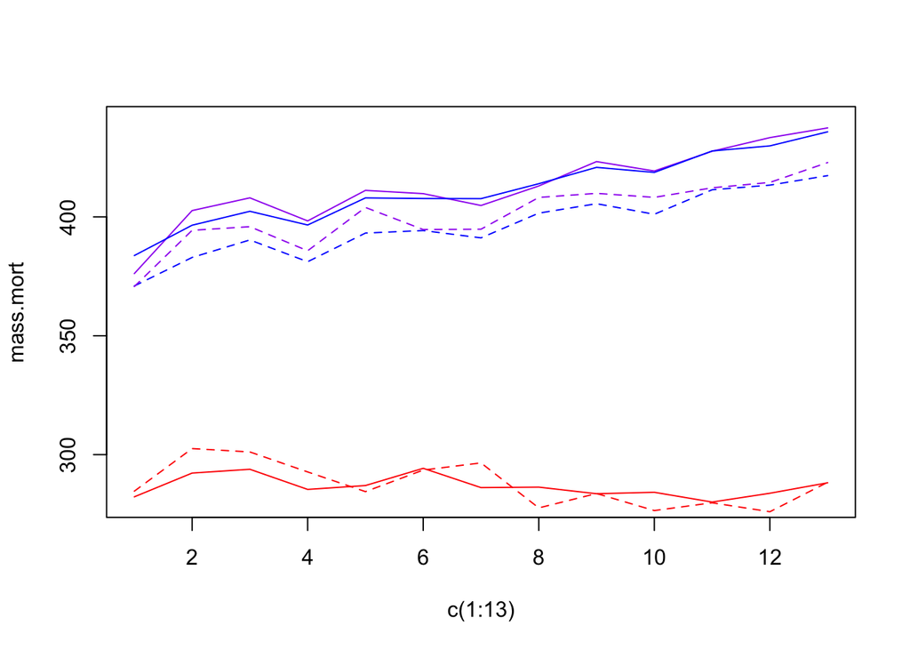

```r
mass.group = merge(deathdata6, model2fit, by=c('state','county'))
mass.group = subset(mass.group, !is.na(fm2))
all.mort = apply(deathdata6[,c(14:19,69:75)],2,mean)
cont.mort = apply(subset(mass.group,mass.group$treat==0)[,c(14:19,69:75)],2,mean)
mass.mort = apply(subset(deathdata6,deathdata6$treat==1)[,c(14:19,69:75)],2,mean)
allm.mort = apply(deathdata6[,c(14:19,69:75)],2,median)
contm.mort = apply(subset(mass.group,mass.group$treat==0)[,c(14:19,69:75)],2,median)
massm.mort = apply(subset(deathdata6,deathdata6$treat==1)[,c(14:19,69:75)],2,median)

plot(c(1:13),mass.mort,ylim=c(280,440),type='l',col='red')
lines(c(1:13),cont.mort,col='purple')
lines(c(1:13),all.mort,col='blue')
lines(c(1:13),massm.mort,type='l',col='red',lty=2)
lines(c(1:13),allm.mort,type='l',col='blue',lty=2)
lines(c(1:13),contm.mort,type='l',col='purple',lty=2)
```

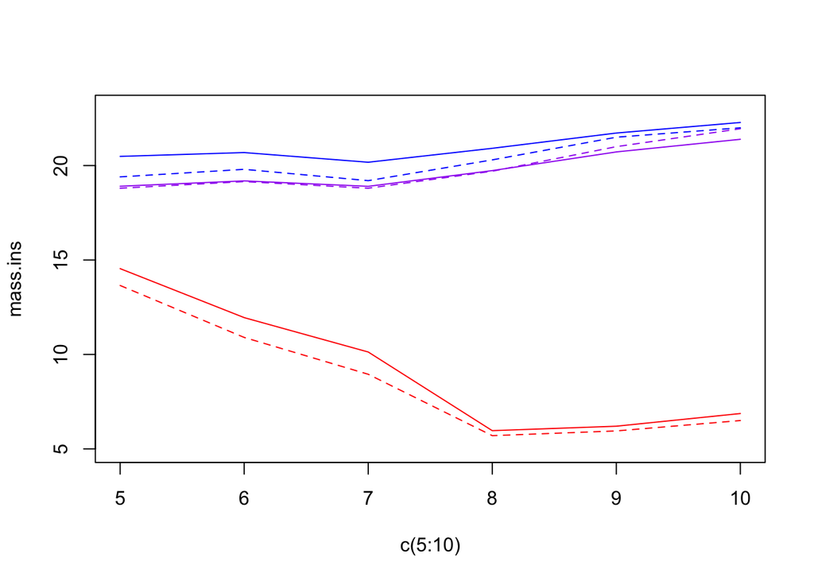

```r
all.ins = apply(deathdata6[,c(46,27,64,63,62,26)],2,mean)
cont.ins = apply(subset(mass.group,mass.group$treat==0)[,c(46,27,64,63,62,26)],2,mean)
mass.ins = apply(subset(deathdata6,deathdata6$treat==1)[,c(46,27,64,63,62,26)],2,mean)
allm.ins = apply(deathdata6[,c(46,27,64,63,62,26)],2,median)
contm.ins = apply(subset(mass.group,mass.group$treat==0)[,c(46,27,64,63,62,26)],2,median)
massm.ins = apply(subset(deathdata6,deathdata6$treat==1)[,c(46,27,64,63,62,26)],2,median)
plot(c(5:10),mass.ins,ylim=c(5,23),type='l',col='red')
lines(c(5:10),cont.ins,col='purple')
lines(c(5:10),all.ins,col='blue')
lines(c(5:10),massm.ins,col='red',lty=2)
lines(c(5:10),contm.ins,col='purple',lty=2)
lines(c(5:10),allm.ins,col='blue',lty=2)
```

The ARF data appear to have no missing variables. In fact, 0s have been imputed for missing variables. In most cases, it appears as if data are missing for the county as a whole, not for a specific year. This will need to be addressed.

As a double check of the strata command within the geese function:

```r
ab = matrix(rnorm(500),nrow=100,ncol=5)
ab = as.data.frame(ab)
idvar = c(rep(1,10),rep(2,10),rep(3,10),rep(4,10),rep(5,10),rep(6,10),rep(7,10),rep(8,10),rep(9,10),rep(10,10))
ce = c(rep('1.1',5), rep('1.2',6), rep('1.3',7),rep('1.4',8),rep('1.5',9),rep('1.6',10),rep('1.7',11),rep('1.8',12),rep('1.9',13),rep('1.10',14),rep('1.11',5))
ce = as.factor(ce)
fg = matrix(0,nrow=100,ncol=11)
fg[c(1:5),1] = 1
fg[c(6:11),2] = 1
fg[c(12:18),3] = 1
fg[c(19:26),4] = 1
fg[c(27:35),5] = 1
fg[c(36:45),6] = 1
fg[c(46:56),7] = 1
fg[c(57:68),8] = 1
fg[c(69:81),9] = 1
fg[c(82:95),10] = 1
fg[c(96:100),11] = 1
colnames(ab) = c('a1','b2','c3','d4','e5')
colnames(fg) = c('s1','s2','s3','s4','s5','s6','s7','s8','s9','s10','s11')
ab1 = cbind(ab,ce,idvar)
ab2 = cbind(ab,fg,idvar)


m11 = geese(a1~b2+c3+d4+e5+strata(ce),data=ab1, id=idvar)
m12 = geese(a1~b2+c3+d4+e5+s2+s3+s4+s5+s6+s7+s8+s9+s10+s11, id=idvar, data=ab2)
summary(m11)
```

```
##
## Call:
## geese(formula = a1 ~ b2 + c3 + d4 + e5 + strata(ce), id = idvar,
##     data = ab1)
##
## Mean Model:
##  Mean Link:                 identity
##  Variance to Mean Relation: gaussian
##
##  Coefficients:
##                     estimate     san.se         wald            p
## (Intercept)    -0.1329125082 0.04233699 9.855797e+00 1.692974e-03
## b2              0.0919804204 0.09703105 8.986060e-01 3.431558e-01
## c3              0.1829101768 0.07388808 6.128116e+00 1.330486e-02
## d4             -0.0005102725 0.08387411 3.701250e-05 9.951459e-01
## e5              0.0620479850 0.14048787 1.950643e-01 6.587347e-01
## strata(ce)1.10 -0.0745284136 0.09068950 6.753513e-01 4.111921e-01
## strata(ce)1.11 -0.2065056826 0.14978803 1.900683e+00 1.680018e-01
## strata(ce)1.2   0.6799841267 0.28190002 5.818450e+00 1.585891e-02
## strata(ce)1.3   0.4910254569 0.06951121 4.989974e+01 1.618039e-12
## strata(ce)1.4   0.1404584907 0.17979340 6.103072e-01 4.346722e-01
## strata(ce)1.5   0.1919080923 0.11234757 2.917825e+00 8.760588e-02
## strata(ce)1.6   0.1067452673 0.11132862 9.193558e-01 3.376442e-01
## strata(ce)1.7   0.6110008085 0.23623918 6.689285e+00 9.699408e-03
## strata(ce)1.8  -0.0549881677 0.28788565 3.648366e-02 8.485201e-01
## strata(ce)1.9   0.3391963807 0.08699528 1.520236e+01 9.658262e-05
##
## Scale Model:
##  Scale Link:                identity
##
##  Estimated Scale Parameters:
##              estimate     san.se     wald p
## (Intercept) 0.7123228 0.07735114 84.80478 0
##
## Correlation Model:
##  Correlation Structure:     independence
##
## Returned Error Value:    0
## Number of clusters:   10   Maximum cluster size: 10
```

```r
summary(m12)
```

```
##
## Call:
## geese(formula = a1 ~ b2 + c3 + d4 + e5 + s2 + s3 + s4 + s5 +
##     s6 + s7 + s8 + s9 + s10 + s11, id = idvar, data = ab2)
##
## Mean Model:
##  Mean Link:                 identity
##  Variance to Mean Relation: gaussian
##
##  Coefficients:
##                  estimate     san.se         wald            p
## (Intercept) -0.1329125082 0.04233699 9.855797e+00 1.692974e-03
## b2           0.0919804204 0.09703105 8.986060e-01 3.431558e-01
## c3           0.1829101768 0.07388808 6.128116e+00 1.330486e-02
## d4          -0.0005102725 0.08387411 3.701250e-05 9.951459e-01
## e5           0.0620479850 0.14048787 1.950643e-01 6.587347e-01
## s2           0.6799841267 0.28190002 5.818450e+00 1.585891e-02
## s3           0.4910254569 0.06951121 4.989974e+01 1.618039e-12
## s4           0.1404584907 0.17979340 6.103072e-01 4.346722e-01
## s5           0.1919080923 0.11234757 2.917825e+00 8.760588e-02
## s6           0.1067452673 0.11132862 9.193558e-01 3.376442e-01
## s7           0.6110008085 0.23623918 6.689285e+00 9.699408e-03
## s8          -0.0549881677 0.28788565 3.648366e-02 8.485201e-01
## s9           0.3391963807 0.08699528 1.520236e+01 9.658262e-05
## s10         -0.0745284136 0.09068950 6.753513e-01 4.111921e-01
## s11         -0.2065056826 0.14978803 1.900683e+00 1.680018e-01
##
## Scale Model:
##  Scale Link:                identity
##
##  Estimated Scale Parameters:
##              estimate     san.se     wald p
## (Intercept) 0.7123228 0.07735114 84.80478 0
##
## Correlation Model:
##  Correlation Structure:     independence
##
## Returned Error Value:    0
## Number of clusters:   10   Maximum cluster size: 10
```